# interpret

fastai’s `Interpretation` for typed decisions (the worst cases, confusion, calibration and coverage), and attributions in the style of transformers-interpret: how much each token, pixel and residue moved each option’s probability, by integrated gradients through a sysone model or by occlusion through any backend.

A trained decider raises three questions, and sysone answers each with its own tools:

- **How good is it?** The metrics: accuracy and macro-F1, calibration, the error of a level, what acting only on sure answers buys.
- **Where is it wrong?** [`Interpretation`](https://sgaseretto.github.io/sysonelib/interpret.html#interpretation), fastai’s: the decisions with the largest losses, the confusions between options, how its confidence compares with how often it is right.
- **Why did it answer that?** Attributions, in the style of transformers-interpret: for each option, how much every token of the row, every pixel of its image and every residue of its protein moved that option’s probability.

```
flowchart LR
    L["a Learner and a split"] -->|Interpretation.from_learner| I[Interpretation]
    D["any backend and records with gold"] -->|Interpretation.from_decider| I
    I --> W["top_losses · plot_top_losses<br/>confusion_matrix · most_confused<br/>classification_report"]
    I --> C["plot_calibration · plot_coverage · metrics"]
    I -->|"explain(i)"| A[Attribution]
    M["a sysone model:<br/>learn.explain · decider.explain"] -->|"integrated gradients,<br/>gradient × input, saliency"| A
    B["any backend"] -->|occlusion| A
    A --> V["a row per option: words coloured,<br/>images and residues drawn"]
```

**TipNew to interpretability? The words this page uses**

Think of a model as a student who has just sat an exam. Metrics are the report card: how many answers were right, and whether the student knew when they were unsure. [`Interpretation`](https://sgaseretto.github.io/sysonelib/interpret.html#interpretation) goes through the marked paper: the worst mistakes, the answers that get mixed up, and whether “90% sure” means right nine times in ten. An attribution asks the student *why*: which words of the question, which parts of the picture, made them answer as they did.

- **Probability, or confidence.** For each question, the model shares out 100% among the options. The option with the largest share is its *answer*, and that share is its *confidence*.
- **Log-odds.** The same belief on another scale, $\log \frac{p}{1-p}$: 0 at 50%, +1 at 73%, +2 at 88%, +3 at 95%, +4.6 at 99%, and the same below zero for the same chances against. Each +1 multiplies the odds by e ≈ 2.7. Attributions are measured in log-odds, since they keep moving where a probability is pinned near 0 or 100%.
- **Loss.** How surprised the model is by the right answer: −log of the probability it gave it. It is 0 at 100%, 0.69 at 50%, 1.61 at 20% (a blind guess among five options) and 4.6 at 1%.
- **Gold.** The right answer, as the data labels it. In typed-decisions it is often a distribution over the options, since annotators disagree, and its likeliest option is the gold label.

Importing `sysone.interpret` adds `explain` to learners and deciders, as importing `sysone.cache` adds `fit_linear`. Below, everything runs on the tiny random fixtures, so the numbers mean nothing and only the mechanics matter. Each output is followed by a note on how to read it and on what it shows here, which is what a model that has learned nothing looks like: worth recognising. The interpretation tutorial runs it on real models: the text application on emotions in tweets, the multimodal application on digits and hot dogs, and the protein application on where proteins live in the cell.

A small text model to look at, trained on the twenty typed-decisions fixtures, with an act head:

```python
from sysone.data import TypedDecisions
from sysone.learner import decision_learner
```

```python
recs = [json.loads(l) for l in Path("fixtures/typed_decisions_tiny.jsonl").read_text().splitlines()]
data = TypedDecisions.from_records(recs, valid=0.25, calib=0.2)
torch.manual_seed(0)
learn = decision_learner(data, "fixtures/tiny-modernbert", train="head", preset="cpu", act=True, loss="soft_ce", calibrate_after_fit=False)
learn.fit(3, lr=3e-3)
learn.calibrate(min_rows=2, act_accuracy=0.5);
```

## Interpretation

[`Interpretation`](https://sgaseretto.github.io/sysonelib/interpret.html#interpretation) holds a split’s decisions as a [`Preds`](https://sgaseretto.github.io/sysonelib/metrics.html#preds), with the record each one came from. `from_learner` reads a learner’s split through `get_preds`, from its feature cache when it has one. `from_decider` asks any backend that answers in the Jev schema: a sysone [`Decider`](https://sgaseretto.github.io/sysonelib/inference.html#decider), a zero-shot decider, a GLiNER2 decider or Laya’s runtime. The verbs are fastai’s, with typed decisions in mind:

- `top_losses` and `plot_top_losses` find the decisions with the largest cross-entropy against the gold: the confident mistakes first.
- `confusion_matrix`, `most_confused` and `classification_report` work on one question at a time, since a question’s options are its classes.
- `plot_calibration` draws the reliability diagram, and `plot_coverage` the accuracy of the answers acted on, surest first, with the act rule’s point on it.
- `metrics` makes a table of any metrics, over all the decisions or per question type, question id or record field.
- `explain(i)` attributes decision `i` (below).

[source](https://github.com/sgaseretto/sysonelib/blob/main/sysone/interpret.py#L31)

### Interpretation

```python
def Interpretation(
    preds:sysone.metrics.Preds, records:dict, decider:NoneType=None, builder:NoneType=None,
    act_threshold:NoneType=None, act_score:NoneType=None
):
```

*fastai’s [`Interpretation`](https://sgaseretto.github.io/sysonelib/interpret.html#interpretation) for typed decisions: a split’s decisions (or a backend’s answers to records) beside their gold, with the records they came from*

```python
interp = Interpretation.from_learner(learn, "valid")
interp
```

```
Interpretation(Preds(25 rows: 7 choice, 10 score, 8 noul · 0 unanswerable · calibrated) · 5 records)
```

### The worst decisions

A decision’s loss is the cross-entropy of its probabilities against its gold distribution, the same number the validation loss averages. A row with no right option has none. `top_losses` returns the losses and their rows, largest first as in fastai, and with `items=True` each row’s record and question id too:

[source](https://github.com/sgaseretto/sysonelib/blob/main/sysone/interpret.py#L82)

### Interpretation.items

```python
def items(
    idxs
)->list:
```

*The record and the question id of each row*

[source](https://github.com/sgaseretto/sysonelib/blob/main/sysone/interpret.py#L75)

### Interpretation.top_losses

```python
def top_losses(
    k:int | None=None, largest:bool=True, items:bool=False
)->tuple:
```

*The `k` largest (or smallest) losses and their rows, and with `items` each row’s record and question id*

[source](https://github.com/sgaseretto/sysonelib/blob/main/sysone/interpret.py#L69)

### Interpretation.losses

```python
def losses()->numpy.ndarray:
```

*Each decision’s cross-entropy against its gold (NaN where none of its options is right)*

```python
l, idx = interp.top_losses(3)
test_eq(len(idx), 3); assert (np.diff(l) <= 0).all()
test_close(np.nanmean(interp.losses), log_loss(interp.preds))
(rec0, qid0), = interp.items(idx[:1])
l, idx, qid0
```

```
(array([1.60944678, 1.60943839, 1.60939457]), array([22,  5,  6]), 'severity')
```

`show_results` draws a card per decision: the input as the model saw it (the text, the image, or the protein’s residues), the question, and the likeliest options beside the gold, the answer in dark blue. [`record_view`](https://sgaseretto.github.io/sysonelib/interpret.html#record_view) decides how to show an input. It looks at the builder’s transforms first (an [`Image`](https://sgaseretto.github.io/sysonelib/template.html#image) or a [`Stream`](https://sgaseretto.github.io/sysonelib/template.html#stream) transform names the state’s image or sequence), and otherwise at the state itself. `plot_top_losses` shows the cards of the largest losses. Like the other `plot_` methods, it returns the figure, which a notebook displays:

[source](https://github.com/sgaseretto/sysonelib/blob/main/sysone/interpret.py#L158)

### Interpretation.plot_top_losses

```python
def plot_top_losses(
    k:int=6, largest:bool=True, ncols:int=3
):
```

*Cards for the `k` decisions with the largest (or smallest) losses*

[source](https://github.com/sgaseretto/sysonelib/blob/main/sysone/interpret.py#L136)

### Interpretation.show_results

```python
def show_results(
    idxs, ncols:int=3
):
```

*Cards for some decisions: the input, the question, and the likeliest options beside the gold*

[source](https://github.com/sgaseretto/sysonelib/blob/main/sysone/interpret.py#L94)

### record_view

```python
def record_view(
    record:dict, builder:NoneType=None
)->tuple:
```

*How to show a record’s input: (‘image’, a PIL image), (‘sequence’, its letters) or (‘text’, the state as text)*

```python
interp.plot_top_losses(4, ncols=2)
```

[figure not shown]

**TipHow to read a card**

Each card is one decision. The grey line names the question, and the bold line gives the gold, the model’s answer and the decision’s loss. On the left is the input as the model saw it. On the right are the likeliest options, each with its probability as a bar: the dark blue bar is the model’s answer, ✓ marks the gold in bold, and ✕ marks the wrong options. A confident mistake shows a long dark bar beside a ✕, and a short bar on the ✓.

Here every option has the same bar, 20% with five options and 25% with four: the model prefers none. Its answer is whichever option is ahead by a hair, a difference far below the rounding, and every loss is a blind guess’s, 1.61 or 1.39.

### Confusions

A question’s options are its classes, so the confusion matrix, `most_confused` and `classification_report` take the question id (`qid`; with one question in the split, it is that one). Classes are the options’ keys, gathered over the question’s rows in the order they first appear. In typed-decisions, the same question id can offer different options in different cases, and then its matrix holds every option it offered.

[source](https://github.com/sgaseretto/sysonelib/blob/main/sysone/interpret.py#L212)

### Interpretation.classification_report

```python
def classification_report(
    qid:NoneType=None
):
```

*Precision, recall, F1 and support of each of a question’s options, then their macro and support-weighted averages*

[source](https://github.com/sgaseretto/sysonelib/blob/main/sysone/interpret.py#L205)

### Interpretation.most_confused

```python
def most_confused(
    qid:NoneType=None, min_val:int=1
)->list:
```

*The off-diagonal cells of one question’s confusion matrix, largest first, as (gold, answer, count)*

[source](https://github.com/sgaseretto/sysonelib/blob/main/sysone/interpret.py#L186)

### Interpretation.plot_confusion_matrix

```python
def plot_confusion_matrix(
    qid:NoneType=None, normalize:bool=False, title:str | None=None, cmap:str='Blues', norm_dec:int=2,
    plot_txt:bool=True
):
```

*One question’s confusion matrix, drawn*

[source](https://github.com/sgaseretto/sysonelib/blob/main/sysone/interpret.py#L176)

### Interpretation.confusion_matrix

```python
def confusion_matrix(
    qid:NoneType=None, normalize:bool=False
):
```

*Gold labels (rows) against answers (columns) for one question, as counts or, normalised, as shares of each gold label*

```python
cm = interp.confusion_matrix("urgency")
test_eq(cm.values.sum(), int(((interp.preds.qids == "urgency") & interp.preds.ok).sum()))
rep = interp.classification_report("urgency")
test_close(rep.loc["macro avg", "f1"], f1_score(interp.preds.select(interp.preds.qids == "urgency")))
test_fail(lambda: interp.confusion_matrix(), contains="name one with qid=")
cm, interp.most_confused("urgency"), rep.round(2)
```

```
(answer  0  1  2  3
 gold
 0       0  1  0  0
 1       1  0  0  1
 2       1  0  0  0
 3       1  0  0  0,
 [('0', '1', 1), ('1', '0', 1), ('1', '3', 1), ('2', '0', 1), ('3', '0', 1)],
               precision  recall   f1  support
 gold
 0                   0.0     0.0  0.0        1
 1                   0.0     0.0  0.0        2
 2                   0.0     0.0  0.0        1
 3                   0.0     0.0  0.0        1
 macro avg           0.0     0.0  0.0        5
 weighted avg        0.0     0.0  0.0        5)
```

```python
interp.plot_confusion_matrix("urgency")
```

[figure not shown]

**TipHow to read a confusion matrix and its report**

Rows are the gold answer, columns the model’s answer, and a cell counts the decisions with that gold and that answer, darker for more. The diagonal holds the right answers. Every other cell is one kind of mistake, read along its row: *gold 1, answered 0*. With `normalize=True` each row is divided by its total, so the diagonal shows the share of each gold answer the model gets right.

The report gives three numbers per option. Think of a smoke alarm: *recall* is the share of real fires it catches, here the share of decisions whose gold is this option that were answered with it. *Precision* is the share of its alarms that were real fires: of the decisions answered with this option, the share that were right. *F1* is their harmonic mean, high only when both are, and *support* counts the decisions whose gold is the option. The macro average weighs every option alike, however rare; the weighted average weighs them by support.

On *urgency* the model is never right. Three of the five decisions are answered 0, and the other two 1 and 3: whichever level it favours by a hair, since it rates all four alike. The one decision whose gold is 0 was answered 1. So the diagonal is empty, and the report’s precision, recall and F1 are 0 for every level.

### Calibration and coverage

The reliability diagram sorts decisions into bins by the probability of their answer, and draws, per bin, how often they were right. A calibrated model’s bars meet the diagonal, and the histogram under it says how many answers each bin holds. With `by="qtype"`, there is a panel per question type, since each type has its own temperatures. `plot_coverage` acts on the surest answers first and draws their accuracy against the share acted on. The point on it is the act rule the learner fitted, which acts where p(act), or the calibrated confidence, reaches its bucket’s threshold (see losses). Acting on an unanswerable row counts as a mistake.

[source](https://github.com/sgaseretto/sysonelib/blob/main/sysone/interpret.py#L263)

### Interpretation.metrics

```python
def metrics(
    metrics:NoneType=None, by:NoneType=None
):
```

*A table of metrics over every decision, and per group with `by`: ‘qtype’, ‘qid’, or a function of the record*

[source](https://github.com/sgaseretto/sysonelib/blob/main/sysone/interpret.py#L246)

### Interpretation.plot_coverage

```python
def plot_coverage(
    score:str | None=None
):
```

*Accuracy on the answers acted on, surest first, against the share acted on, with the act rule’s point when there is one*

[source](https://github.com/sgaseretto/sysonelib/blob/main/sysone/interpret.py#L226)

### Interpretation.plot_calibration

```python
def plot_calibration(
    bins:int=10, by:str | None=None
):
```

*A reliability diagram: how often answers are right against how sure they are, bin by bin, over the answers each bin holds (a panel per question type with `by='qtype'`)*

```python
interp.plot_calibration(by="qtype")
```

[figure not shown]

**TipHow to read a reliability diagram, and what ECE is**

A weather forecaster is *calibrated* when, of all the days they gave a 70% chance of rain, it rained on about 70%. A model is calibrated in the same way when, of the answers it gives at 70%, about 70% are right. The diagram checks this. It sorts the answers into ten bins by their confidence, the x axis (0 to 10%, 10 to 20%, and so on), and each bar shows the share right in its bin, the y axis. The dashed diagonal is perfect calibration. A bar under it is *overconfident*: those answers are right less often than they claim. A bar over it is *underconfident*. The histogram below counts the answers in each bin, since a bar over a handful of answers says little.

The *expected calibration error* (ECE) sums the diagram up. In each bin it takes the gap between the average confidence and the share right, and averages the gaps over the bins, weighted by how many answers each holds. With $n_b$ of the $N$ answers in bin $b$:

$$\mathrm{ECE} = \sum_b \frac{n_b}{N}\,\big|\,\mathrm{acc}_b - \mathrm{conf}_b\,\big|$$

0 is perfect, and 0.10 means the stated confidence is off by 10 points on average. Calibration is honesty, not skill: a model that gives each of five options 20%, and so is right 20% of the time, is perfectly calibrated and useless. Read ECE beside accuracy.

Each panel holds a single bar, since every answer of a type sits in the same bin: the model gives the options of a question equal shares, 20 to 25% for the choice and score questions and 50% for the two options of a noul (a yes-or-no statement). Its choice answers claim about 24% and are right one time in seven, 14%: an ECE of 0.093. The score answers claim about 25% and are right two times in ten, 0.045. The noul answers claim 50% and are right two times in eight, 0.250. With a single bar, the ECE is the distance from its top to the diagonal.

```python
interp.plot_coverage()
```

[figure not shown]

**TipHow to read a coverage plot**

Suppose the model may hand a decision to a person when it is unsure, as a junior doctor refers the hard cases to a specialist. Sort its decisions from the surest to the least sure, and act only on the surest share. The x axis is that share, the *coverage*, from a few decisions on the left to all of them on the right. The blue curve is the accuracy of the decisions acted on. When the model’s sureness is worth trusting, the curve starts high on the left and comes down to the overall accuracy at the right, where everything is acted on: the dashed line. The red dot is the rule the learner fitted for when to act, placed at how much it acts on and how often it is right when it does. A useful rule sits well above the dashed line, trading coverage for accuracy.

Here the sureness is the *act head*’s: a small part of the model trained to say whether its answer can be acted on, p(act). Its curve stays near the dashed line, at 0.20, and starts at 0, so the decisions it was surest of were wrong. The fitted rule acts on 36% of the decisions and is right on about one in ten of them, worse than acting on everything. An untrained act head’s sureness carries no information, and its thresholds were fitted on a calibration split of a few records.

```python
interp.metrics([accuracy, F1Score(), log_loss, brier_score, ece, aurc], by=lambda r: r["workflow"]).round(3)
```

|  | accuracy | f1_score | log_loss | brier_score | ece | aurc | rows |
| --- | --- | --- | --- | --- | --- | --- | --- |
| all | 0.2 | 0.148 | 1.191 | 0.260 | 0.124 | 0.722 | 25 |
| agent_trace_observability | 0.2 | 0.200 | 1.248 | 0.261 | 0.100 | 0.843 | 5 |
| customer_service | 0.0 | 0.000 | 1.337 | 0.316 | 0.280 | 1.000 | 5 |
| invoice_processing | 0.4 | 0.267 | 1.109 | 0.328 | 0.050 | 0.579 | 10 |
| security_incidents | 0.0 | 0.000 | 1.154 | 0.066 | 0.340 | 1.000 | 5 |

The table reads like a report card, a row per group of decisions: all 25 first, then each workflow of the fixture.

- *accuracy* is the share answered right, and *f1_score* the macro-F1 of the report above.
- *log_loss* is the average loss. A blind guess scores the log of the number of options, 1.39 for four and 1.61 for five, and lower is better.
- *brier_score* is the squared distance between the probabilities and the gold distribution, summed over the options: 0 is perfect.
- *ece* is the calibration error, here over fifteen bins.
- *aurc*, the area under the risk–coverage curve, is the error rate of the decisions acted on, averaged over every coverage of the plot above. With a sureness worth trusting it is well below the error rate; with a useless one it is about equal to it.
- *rows* counts the decisions.

On the fixture, every number is near chance: an accuracy of 0.2, a log-loss near a blind guess’s, and an AURC of 0.72 against an error rate of 0.8. The Brier score is low on some workflows despite an accuracy of 0, since the fixture’s gold is a distribution spread over the options, which equal probabilities come close to. And five decisions per workflow are too few to compare workflows anyway.

`from_decider` scores any backend the same way, from its answers. Here it is the learner’s own [`Decider`](https://sgaseretto.github.io/sysonelib/inference.html#decider) over all twenty fixture records, and the shared metrics agree with [`evaluate`](https://sgaseretto.github.io/sysonelib/evaluate.html#evaluate):

```python
from sysone.evaluate import evaluate
```

```python
dec = learn.decider()
ivd = Interpretation.from_decider(dec, recs)
ev = evaluate(dec, recs)
test_close(accuracy(ivd.preds), ev["accuracy"]); test_close(f1_score(ivd.preds), ev["macro_f1"])
ivd
```

```
Interpretation(Preds(100 rows: 30 choice, 40 score, 30 noul · 0 unanswerable · T = 1) · 20 records)
```

## Attributions

An attribution answers *why this option?* for one decision. For each option it explains, it gives every unit of the input a number: a token of the row, a pixel of its image, a residue of its protein. A positive number means the unit raised that option’s log-odds, and a negative one that it lowered them. sysone computes attributions two ways.

**TipAttributions in plain words**

An attribution is a model’s answer to *why?*, given as a number for every part of its input. Think of a doctor reading an X-ray: an attribution would colour green the regions that made the diagnosis likelier, and red those that spoke against it. For text the parts are words (or the tokens they are cut into), for an image its pixels, and for a protein its residues.

The two kinds below ask in different ways. *Occlusion* is the experiment anyone could run: cover one word, or one patch of the picture, and see how far the model’s belief falls. *Integrated gradients* asks the model’s arithmetic instead. Starting from a blank input that says nothing, the *baseline*, it fades the real input in step by step, and adds up how hard each part pushed each option along the way. Both count in log-odds: +1 means the part multiplied that option’s odds by about 2.7, and −1 divided them by as much.

- **Through the model**, with its gradients: integrated gradients, gradient × input, and saliency. These need a sysone model (a [`Learner`](https://sgaseretto.github.io/sysonelib/learner.html#learner)’s, or a [`Decider`](https://sgaseretto.github.io/sysonelib/inference.html#decider)’s), since they run backwards through it, and they score every unit of every input at once.
- **Through any backend**, by occlusion: hide one piece of the state at a time, ask again, and see how far each option’s probability falls. It needs nothing but [`predict`](https://sgaseretto.github.io/sysonelib/cli.html#predict), so it works for zero-shot deciders, GLiNER2 and Laya’s runtime too, and its numbers are the model’s real answers on the changed inputs.

### What a row is made of

A decision row is a template’s text, `[CLS] choice question: … [SEP] [MASK] option 1 [MASK] option 2 … [SEP] state [SEP]`, plus an image or a side stream when the encoder reads one. To show an attribution, the tokens need their text, and each needs a role. [`token_texts`](https://sgaseretto.github.io/sysonelib/interpret.html#token_texts) decodes each token as it reads in place, with the space before it, by decoding it after its neighbour. [`row_segments`](https://sgaseretto.github.io/sysonelib/interpret.html#row_segments) labels every position:

- `question`: the type and the instructions;
- `anchor i`: the anchor of option `i`, which the head reads;
- `option i`: option `i`’s own text;
- `state`, located by its own token ids;
- `special`: the template’s markers and an image’s placeholders.

[source](https://github.com/sgaseretto/sysonelib/blob/main/sysone/interpret.py#L301)

### row_segments

```python
def row_segments(
    builder:sysone.template.RowBuilder, row:sysone.core.Row, record:dict
)->list:
```

*What each position of a row holds: ‘question’, ‘anchor i’, ‘option i’, ‘options’ (between options), ‘state’ or ‘special’*

[source](https://github.com/sgaseretto/sysonelib/blob/main/sysone/interpret.py#L293)

### special_ids

```python
def special_ids(
    builder:sysone.template.RowBuilder
)->set:
```

*The ids a row’s builder puts in itself: the tokenizer’s special tokens, the template’s, and an adapter’s image tokens*

[source](https://github.com/sgaseretto/sysonelib/blob/main/sysone/interpret.py#L269)

### token_texts

```python
def token_texts(
    tok, ids
)->list:
```

*Each token as it reads in the decoded text: with the space before it, a word piece without its marker*

```python
b = learn.data.builder
rec = apply_tfms(b.tfms, load_record(recs[0]))
row = b.build_record({**rec, "questions": {"action": rec["questions"]["action"]}}, tfms=False)[0]
texts, segs = token_texts(b.tok, row.ids), row_segments(b, row, rec)
test_eq("".join(texts), b.tok.decode(row.ids))
test_eq([segs[m] for m in row.markers], [f"anchor {j}" for j in range(row.k)])
assert {"special", "question", "anchor", "option", "state"} <= {s.split()[0] for s in segs}
test_eq("".join(t for t, s in zip(texts, segs) if s == "state").strip()[:40], render_state(rec["state"])[:40])
list(zip(texts, segs))[:14]
```

```
[('[CLS]', 'special'),
 ('ch', 'question'),
 ('o', 'question'),
 ('ice', 'question'),
 (' que', 'question'),
 ('s', 'question'),
 ('tion', 'question'),
 (':', 'question'),
 (' ', 'question'),
 ('What', 'question'),
 (' should', 'question'),
 (' the', 'question'),
 (' observability', 'question'),
 (' system', 'question')]
```

The tiny tokenizer cuts *choice question:* into pieces, *ch*, *o*, *ice*, *que*, *s*, *tion*. Models read word pieces rather than words, and `words` joins the pieces of a word back together. Each piece carries the part of the row it belongs to: here the template’s `[CLS]` marker, then the question.

### Integrated gradients

A gradient says how an output moves when an input moves a little, and so it describes the model only near the input. Integrated gradients ([Sundararajan et al., 2017](https://arxiv.org/abs/1703.01365)), which transformers-interpret computes, asks how the output got there. It walks a straight line from a *baseline* $x'$, an input that says nothing, to the input $x$, and adds up the gradient along the way:

$$\mathrm{IG}_i = (x_i - x'_i) \int_0^1 \frac{\partial f\big(x' + \alpha (x - x')\big)}{\partial x_i}\, d\alpha$$

For an embedding, the attribution of a token is the sum of $\mathrm{IG}_i$ over the embedding’s coordinates. Its main property is *completeness*: the attributions add up to $f(x) - f(x')$, the whole change of the output from the baseline to the input. So the attributions can be checked. When they don’t add up, the integral was not computed well, and the gap is reported.

Every choice here is about the line:

```
flowchart LR
    R["one row"] -->|"repeated: one copy per α"| B["a batch"]
    B --> E["embedding layer"]
    E -.->|"forward hook: x' + α (x − x')"| T["the encoder and the head"]
    T --> F["the log-odds of each option explained"]
    F -->|"backward, one option at a time"| G["gradients at every α"]
    G -->|"weighted sum × (x − x')"| A["an attribution per token,<br/>per pixel, per residue"]
```

`gradient × input` is one gradient, at the input, times $(x - x')$. It is cheap, but it ignores the way there. `saliency` is the size of the gradient at the input, with no baseline and no sign.

[figure not shown]

The row’s state fading in from [PAD] along the line, and an option’s log-odds along it: on a smooth curve the rule’s weighted slopes add up to the change, on a jagged one they don’t

The line, drawn (figures). Above, a row at five points of it: only the state moves, from `[PAD]` to its own tokens. Below, an option’s log-odds along the line, on two stand-in curves, with the eight points of `gauss_legendre(8)` and the slope at each. Summed over every token, the attributions are the rule’s weighted sum of these slopes, so completeness holds when that sum matches Δ, the change from the baseline to the row. On a smooth curve it does. On a jagged one, eight slopes can say almost anything, here even the wrong sign; that is what the ⚠ in an attribution’s table catches.

[source](https://github.com/sgaseretto/sysonelib/blob/main/sysone/interpret.py#L336)

### gradients_through

```python
def gradients_through(
    model
):
```

*While attributing: gradients reach a frozen encoder’s inputs, dropout is off, and every side encoder encodes each row of a batch*

[source](https://github.com/sgaseretto/sysonelib/blob/main/sysone/interpret.py#L330)

### gauss_legendre

```python
def gauss_legendre(
    n:int
)->tuple:
```

*The nodes and weights of the n-point Gauss–Legendre rule on [0, 1]*

[source](https://github.com/sgaseretto/sysonelib/blob/main/sysone/interpret.py#L326)

### stream_embeddings

```python
def stream_embeddings(
    encoder, name:str
)->torch.nn.modules.module.Module:
```

*The module whose output is a side stream’s token embeddings*

[source](https://github.com/sgaseretto/sysonelib/blob/main/sysone/interpret.py#L321)

### input_embeddings

```python
def input_embeddings(
    encoder
)->torch.nn.modules.module.Module:
```

*The module whose output is a row’s token embeddings: what an attribution moves along its line for the tokens*

```python
x, w = gauss_legendre(8)
test_close(w.sum(), 1.0); test_close((w * x ** 15).sum(), 1 / 16)       # exact for polynomials up to degree 2n - 1
test_eq(type(input_embeddings(learn.model.encoder)).__name__, "Embedding")
```

**NoteFinding: a batch of integrated-gradient steps went through a side encoder as one row**

A side encoder, such as the protein application’s ESM, encodes each distinct input of a batch once (see models), since a protein asked several questions sits in several rows. The steps of an integrated gradient are one row repeated, so the encoder ran once, while the hook on its embeddings returned a point on the line for every step: the shapes no longer matched. Side encoders now have a `dedupe` switch, which [`gradients_through`](https://sgaseretto.github.io/sysonelib/interpret.html#gradients_through) turns off while it attributes. [`gradients_through`](https://sgaseretto.github.io/sysonelib/interpret.html#gradients_through) also lifts the frozen encoder’s `no_grad` and turns dropout off.

[`attribute`](https://sgaseretto.github.io/sysonelib/interpret.html#attribute) builds the row of one question exactly as the [`Decider`](https://sgaseretto.github.io/sysonelib/inference.html#decider) builds it, with the same transforms. It finds the inputs the row has, sets up a line for each, and returns an [`Attribution`](https://sgaseretto.github.io/sysonelib/interpret.html#attribution). Its options default to all of them up to six, else the three likeliest and the gold. Each option costs one backward pass per batch of steps, while the forward pass is shared. Before the steps run, one forward and backward pass with a single step measures the memory autograd keeps per step, from the tensors it saves, leaving out the weights. `batch_size=None` then fits as many steps per batch as 2 GB holds.

[source](https://github.com/sgaseretto/sysonelib/blob/main/sysone/interpret.py#L468)

### attribute

```python
def attribute(
    model, builder:sysone.template.RowBuilder, state, questions:dict, qid:NoneType=None, method:str='ig',
    options:NoneType=None, target:str='logodds', inputs:NoneType=None, n_steps:int=32, batch_size:int | None=None,
    baseline:str='pad', temperatures:dict | None=None, gold:NoneType=None, memory:float=2.0
):
```

*How much every token (pixel, residue) moved each option’s log-odds, for one question of one record: integrated gradients (‘ig’), ‘grad_x_input’ or ‘saliency’*

[source](https://github.com/sgaseretto/sysonelib/blob/main/sysone/interpret.py#L429)

### log_odds

```python
def log_odds(
    z
):
```

*Each option’s log-odds against the others, log p / (1 − p): its logit less the log-sum-exp of the other logits (batch, K)*

[source](https://github.com/sgaseretto/sysonelib/blob/main/sysone/interpret.py#L363)

### black_row

```python
def black_row(
    builder:sysone.template.RowBuilder, record:dict, row:sysone.core.Row
)->sysone.core.Row:
```

*The same row with its image painted black, as the processor encodes it: the baseline of a pixel attribution*

[source](https://github.com/sgaseretto/sysonelib/blob/main/sysone/interpret.py#L359)

### SequencePart

```python
def SequencePart(
    units:list, scores:numpy.ndarray, name:str='stream'
)->None:
```

*A side stream’s units, such as a protein’s residues, and each one’s attribution for every option explained (options × units)*

[source](https://github.com/sgaseretto/sysonelib/blob/main/sysone/interpret.py#L354)

### ImagePart

```python
def ImagePart(
    images:list, scores:list, name:str='pixels'
)->None:
```

*An image as the encoder reads it (one array in [0, 1] per view), and each pixel’s attribution for every option explained (per view: options × H × W)*

[source](https://github.com/sgaseretto/sysonelib/blob/main/sysone/interpret.py#L349)

### TokenPart

```python
def TokenPart(
    texts:list, segments:list, scores:numpy.ndarray, name:str='tokens'
)->None:
```

*A row’s tokens (or a text’s words), what each one is, and its attribution for every option explained (options × tokens)*

```python
z3 = torch.tensor([[1.0, 0.0, -1.0]])
test_close(log_odds(z3), torch.log(torch.softmax(z3, -1) / (1 - torch.softmax(z3, -1))), eps=1e-5)      # log p / (1 − p)
test_eq(log_odds(torch.tensor([[2.0, 0.5]])).tolist(), [[1.5, -1.5]])                                 # two options: the difference of the logits
test_close(log_odds(torch.tensor([[30.0, 0.0]]))[0, 0], 30.0)                                           # an answer at 1 − 1e-13 still has log-odds that move
```

### Attribution

An [`Attribution`](https://sgaseretto.github.io/sysonelib/interpret.html#attribution) holds the question, every option’s probability, the options it explains, and a part per input: [`TokenPart`](https://sgaseretto.github.io/sysonelib/interpret.html#tokenpart), [`ImagePart`](https://sgaseretto.github.io/sysonelib/interpret.html#imagepart) or [`SequencePart`](https://sgaseretto.github.io/sysonelib/interpret.html#sequencepart). In a notebook it shows as transformers-interpret shows one, a row per option explained. Each row has the option’s probability and, for integrated gradients, the change of its log-odds from the baseline to the input ($f(x) - f(x')$) beside the sum of the attributions, which should be equal. Then come the row’s words, green where they raised the option and red where they lowered it. As in transformers-interpret, each row’s shades are relative to its own largest attribution, its *scale*, so an option whose attributions are small still shows which words it rests on. A word’s number shows when the pointer rests on it. Images and proteins follow as figures, from [`part_figure`](https://sgaseretto.github.io/sysonelib/interpret.html#part_figure), a generic function on the part’s kind. `by_segment` says how each option’s attribution splits between the question, the options, the state, and the image or the protein. `words` lists `(word, score, segment)` for one option.

[source](https://github.com/sgaseretto/sysonelib/blob/main/sysone/interpret.py#L577)

### Attribution.words

```python
def words(
    option:NoneType=None, part:str='tokens', segments:NoneType=None
)->list:
```

*(word, score, segment) for one option (the first explained by default): the tokens joined into words, their scores summed*

[source](https://github.com/sgaseretto/sysonelib/blob/main/sysone/interpret.py#L559)

### Attribution.by_segment

```python
def by_segment():
```

*The share of each option’s absolute attribution in each segment of the row (question, options, state) and in each other input*

[source](https://github.com/sgaseretto/sysonelib/blob/main/sysone/interpret.py#L554)

### Attribution.totals

```python
def totals()->dict:
```

*Each part’s summed attribution, per option explained: with integrated gradients, together they make f(input) − f(baseline)*

[source](https://github.com/sgaseretto/sysonelib/blob/main/sysone/interpret.py#L523)

### Attribution

```python
def Attribution(
    question, probs, options, parts:dict, method:str, target:str, gold:int=-1, delta:NoneType=None,
    f_input:NoneType=None, f_baseline:NoneType=None, record:NoneType=None, batch_size:NoneType=None
):
```

*What drove one decision: for each option explained, a score for every unit (token, word, pixel, residue) of every input*

[source](https://github.com/sgaseretto/sysonelib/blob/main/sysone/interpret.py#L612)

### attribution_html

```python
def attribution_html(
    a:__main__.Attribution, segments:NoneType=None, by_word:bool=True
)->str:
```

*An attribution as HTML: a row per option explained, its words green where they raise its log-odds and red where they lower them, then its images and sequences*

`learn.explain` and `decider.explain` are the shortcuts, with the decider’s model, row builder and temperatures. Any method goes through [`attribute`](https://sgaseretto.github.io/sysonelib/interpret.html#attribute), and `method="occlusion"` through [`occlusion`](https://sgaseretto.github.io/sysonelib/interpret.html#occlusion), which comes below:

[source](https://github.com/sgaseretto/sysonelib/blob/main/sysone/interpret.py#L692)

### Learner.explain

```python
def explain(
    state, questions:dict, qid:NoneType=None, method:str='ig', **kw
)->__main__.Attribution:
```

*Why this learner’s model answers as it does (see [`Decider.explain`](https://sgaseretto.github.io/sysonelib/interpret.html#decider.explain))*

[source](https://github.com/sgaseretto/sysonelib/blob/main/sysone/interpret.py#L686)

### Decider.explain

```python
def explain(
    state, questions:dict, qid:NoneType=None, method:str='ig', **kw
)->__main__.Attribution:
```

*Why this decider answered as it did: [`attribute`](https://sgaseretto.github.io/sysonelib/interpret.html#attribute) (integrated gradients by default) through its model, or [`occlusion`](https://sgaseretto.github.io/sysonelib/interpret.html#occlusion) through its answers*

```python
torch.manual_seed(0)
a = learn.explain(recs[0]["state"], recs[0]["questions"], "action", gold=recs[0]["gold"]["action"])
test_eq(set(a.parts), {"tokens"})
test_eq(a.parts["tokens"].scores.shape, (len(a.options), len(a.parts["tokens"].texts)))
test_close(a.totals()["tokens"], a.f_input - a.f_baseline, eps=1e-3)           # completeness, on the fixture's smooth little model
test_close(a.by_segment().sum(1).values, np.ones(len(a.options)))
test_eq(a.options, list(np.argsort(-a.probs)))                                   # four options: every one, likeliest first
a
```

[output not shown]

**What should the observability system do with this trace?** · answer **human_review** (25%) · gold **human_review** · ig, attributions of log-odds

| option | p | Δ | Σ | scale | words |
| --- | --- | --- | --- | --- | --- |
| **human_review** ✓ | 0.25 | +0.00011 | +9.1e-05 | 2.8e-05 | [CLS] choice question: What should the observability system do with this trace? [SEP] ▸ continue: Let the agent proceed without interruption. ▸ human_review: Queue this trace for a human to review. ▸ … |
| **continue** | 0.25 | +6.3e-05 | +3.5e-05 | 4.1e-05 | [CLS] choice question: What should the observability system do with this trace? [SEP] ▸ continue: Let the agent proceed without interruption. ▸ human_review: Queue this trace for a human to review. ▸ … |
| **stop** | 0.25 | -7.4e-05 | +2.2e-06 | 3.4e-05 | [CLS] choice question: What should the observability system do with this trace? [SEP] ▸ continue: Let the agent proceed without interruption. ▸ human_review: Queue this trace for a human to review. ▸ … |
| **observe** | 0.25 | -9.9e-05 | -0.00013 | 2.5e-05 | [CLS] choice question: What should the observability system do with this trace? [SEP] ▸ continue: Let the agent proceed without interruption. ▸ human_review: Queue this trace for a human to review. ▸ … |

**TipHow to read an attribution**

The first line says what is explained: the question, the model’s answer with its probability, the gold, the method (`ig` is integrated gradients), and what the numbers measure (log-odds). Then each row is one option, the gold marked ✓.

- **p** is the option’s probability.
- **Δ** is how far the option’s log-odds moved from the baseline row, with every word blanked, to the real row: everything the input did for that option.
- **Σ** is the sum of all the attributions in the row. For integrated gradients it must equal Δ, as a receipt’s items must add up to its total. When they don’t, ⚠ marks the row (the gap is over 0.1 plus 10% of Δ), and its colours are not to be trusted.
- **scale** is the row’s largest attribution, as a size: a word coloured at full strength moved the log-odds by that much.
- **words** is the row as the model read it. A green word raised the option’s log-odds and a red one lowered them; the stronger the colour, the larger its share of the scale. Grey words are the template’s own markers, and ▸ is the anchor where the model reads each option. Resting the pointer on a word shows its number.

Each row’s colours are relative to its own scale, so colours can’t be compared between rows. Read the scale first: a deep green under a scale of 0.0001 means less than a pale one under a scale of 5.

Here the scales are about 3 × 10⁻⁵, and Δ and Σ about 10⁻⁴: the whole input moved each option’s log-odds by a ten-thousandth, and every option stays at 25%. The vivid greens and reds are this noise, stretched over each row’s colour range. In absolute terms the sums match the changes to within 10⁻⁴, which is all the check asks; relative to changes this small they don’t, and stop’s sum even has the opposite sign of its change. At this scale there is nothing to explain, which is the point of reading the scale first.

On this tiny model the attributions add up to the change of each option’s log-odds, to a thousandth, with the default 32 steps. Gradient × input and saliency are one backward pass each:

```python
gx = learn.explain(recs[0]["state"], recs[0]["questions"], "action", method="grad_x_input", options=["stop"])
sal = learn.explain(recs[0]["state"], recs[0]["questions"], "action", method="saliency", options=["stop"])
test_eq((gx.delta, gx.options), (None, [as_questions(recs[0]["questions"])["action"].keys.index("stop")]))
assert (sal.parts["tokens"].scores >= 0).all()
test_fail(lambda: learn.explain(recs[0]["state"], recs[0]["questions"], "action", options=["stop"]).words("observe"), contains="was not explained")
sorted(gx.words("stop", segments=("state",)), key=lambda w: -abs(w[1]))[:5]
```

```
[('"internal-agent-v4"},', -8.327579735123436e-06, 'state'),
 ('"checkpointed",', -7.907372037152527e-06, 'state'),
 ('"constraints":', -6.177707746246597e-06, 'state'),
 ('"model":', -5.720991794078145e-06, 'state'),
 ('{"agent":', -4.329238890932174e-06, 'state')]
```

These are the five words of the state with the largest gradient × input for *stop*, each lowering its log-odds by a few millionths: noise again.

### Pixels and proteins

A row with an image has a second line, through its pixels. Its baseline is the same image painted black: a black image of the same size, made into pixels by the processor ([`black_row`](https://sgaseretto.github.io/sysonelib/interpret.html#black_row)), so that tiles and padding line up. [`pixel_tiles`](https://sgaseretto.github.io/sysonelib/template.html#pixel_tiles), a generic function on the processor, turns the pixels and their attributions back into the image. ModernVBERT’s method stitches the tiles back together and adds the global view; NeoMME’s puts its patches back on their grid. [`part_figure`](https://sgaseretto.github.io/sysonelib/interpret.html#part_figure) averages the map over cells of 1/32 of the image before drawing it, since an attribution per pixel is speckled. Each map’s colours run to the 98th percentile of its sizes, so that a few extreme pixels don’t wash the rest out, as Captum’s visualisations clip outliers, and a cell’s colour is more opaque the larger its attribution, so the image shows through where nothing happens.

On the fixture’s tiny ModernVBERT, colours to tell apart. The state is an image and no text, so by default the image alone moves; with `inputs=["tokens", "pixels"]` the row’s tokens move with it, and `by_segment` splits each option’s attribution between the question, the options and the pixels:

```python
from PIL import Image as PILImage
from sysone.multimodal import decision_learner as mm_learner
```

```python
tmp = Path(tempfile.mkdtemp())
COLOURS = {"red": (200, 30, 30), "green": (30, 170, 60), "blue": (40, 60, 200)}
cq = {"colour": {"type": "choice", "instructions": "Which colour fills the image?", "criteria": list(COLOURS)}}
crecs = []
for i in range(24):
    name = list(COLOURS)[i % 3]
    p = tmp / f"{i}.png"; im = PILImage.new("RGB", (40 + 7 * i, 40), COLOURS[name]); im.paste((255, 255, 255), (4, 4, 14, 14)); im.save(p)
    crecs.append({"id": f"c{i}", "state": {"text": "", "image": str(p)}, "questions": cq, "gold": {"colour": name}})
cdata = TypedDecisions.from_records(crecs, valid=0.25, calib=0.25, seed=0)
torch.manual_seed(0)
ml = mm_learner(cdata, "fixtures/tiny-modernvbert", image_side=64, preset="cpu", loss="soft_ce", cache_dir=tempfile.mkdtemp(), calibrate_after_fit=False)
ml.fit(3, lr=3e-3)
test_eq(set(ml.explain(crecs[5]["state"], cq, options=["blue"]).parts), {"pixels"})          # the state is an image and no text
ia = ml.explain(crecs[5]["state"], cq, gold="blue", inputs=["tokens", "pixels"])
test_eq(set(ia.parts), {"tokens", "pixels"})
test_eq(ia.parts["pixels"].images[0].shape[:2], ia.parts["pixels"].scores[0].shape[1:])
test_close(sum(ia.totals().values()), ia.f_input - ia.f_baseline, eps=1e-3)       # tokens and pixels add up together
ia.by_segment().round(3)
```

|  | question | options | pixels |
| --- | --- | --- | --- |
| blue | 0.262 | 0.070 | 0.668 |
| red | 0.057 | 0.028 | 0.915 |
| green | 0.165 | 0.059 | 0.776 |

Each row splits one option’s attribution, as sizes, among the parts of the row, so it sums to 1. For *blue*, 67% of what moved its log-odds came from the pixels, 26% from the question’s words and 7% from the options’: the answer rests mostly on the image, as it should for a question about colour. *red* rests on the pixels even more, 92%.

**Which colour fills the image?** · answer **blue** (34%) · gold **blue** · ig, attributions of log-odds

| option | p | Δ | Σ | scale | words |
| --- | --- | --- | --- | --- | --- |
| **blue** ✓ | 0.34 | +0.02 | +0.02 | 0.0013 | [CLS] choice question: Which colour fills the image? [SEP] ▸ red ▸ green ▸ blue [SEP] <fake_token_around_image> <global-img> <image>×4 <fake_token_around_image> [SEP] |
| **red** | 0.33 | +0.0028 | +0.0029 | 0.0012 | [CLS] choice question: Which colour fills the image? [SEP] ▸ red ▸ green ▸ blue [SEP] <fake_token_around_image> <global-img> <image>×4 <fake_token_around_image> [SEP] |
| **green** | 0.33 | -0.03 | -0.03 | 0.0017 | [CLS] choice question: Which colour fills the image? [SEP] ▸ red ▸ green ▸ blue [SEP] <fake_token_around_image> <global-img> <image>×4 <fake_token_around_image> [SEP] |

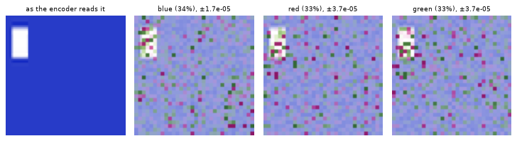

```python
ia
```

**TipHow to read an image attribution**

The first panel is the image as the encoder reads it: resized, and for some encoders cut into tiles. Each next panel is one option’s map over it, titled with the option, its probability, and ± the attribution at which the colours reach full strength. Green marks pixels that raised the option’s log-odds, pink pixels that lowered them, and where pixels did neither the image shows through, faded (so black looks grey). The map is averaged over square cells 1/32 of the image wide, which is why it looks blocky, and its colours stop growing at the 98th percentile of its values, so that a few extreme cells don’t wash out the rest. As with words, each map has its own scale.

The model gives blue, red and green 34%, 33% and 33%: it can barely tell them apart, so the table’s changes are hundredths. Its maps run to ±2 to 4 × 10⁻⁵ per pixel, and green and pink speckle the plain blue background as much as anywhere. The white square, the image’s only feature besides its colour, holds some of the strongest cells in every map, and decides nothing: every option stays near a third.

A protein is a side stream: ESM reads its residues, and the head scores each option against the protein’s pooled vector. Its line runs through ESM’s embeddings, from every residue masked to the protein:

```python
from sysone.protein import decision_learner as prot_learner, load_protst
```

```python
LOCS = {"nucleus": "SUBCELLULAR LOCATION: Nucleus.", "cytoplasm": "SUBCELLULAR LOCATION: Cytoplasm.", "membrane": "SUBCELLULAR LOCATION: Cell membrane."}
PQ = {"location": {"type": "choice", "instructions": "Where in the cell is this protein found?", "criteria": LOCS}}
AA, rng = "ACDEFGHIKLMNPQRSTVWY", np.random.default_rng(0)
def fixture_protein(i):
    c = i % 3
    seq = "M" + "".join(rng.choice(list(AA[5 * c:5 * c + 5] if rng.random() < 0.5 else AA)) for _ in range(rng.integers(30, 60)))
    return {"id": f"p{i}", "state": {"sequence": seq}, "questions": PQ, "gold": {"location": list(LOCS)[c]}}
precs = [fixture_protein(i) for i in range(30)]
pdata = TypedDecisions.from_records(precs, valid=0.25, calib=0.25, seed=0)
torch.manual_seed(0)
pl = prot_learner(pdata, load_protst("fixtures/tiny-protst"), preset="cpu", loss="soft_ce", cache_dir=tempfile.mkdtemp(), calibrate_after_fit=False)
pl.fit(3, lr=3e-3)
pa = pl.explain(precs[1]["state"], PQ, gold=precs[1]["gold"]["location"], n_steps=64)
test_eq(set(pa.parts), {"stream:protein"})                                                  # the state is the protein alone
test_eq(len(pa.parts["stream:protein"].units), len(precs[1]["state"]["sequence"]) + 2)        # the residues, between <cls> and <eos>
test_eq(pl.model.encoder.sides["protein"].dedupe, True)                                     # back on once the attribution is done
pa.by_segment().round(3)
```

|  | stream:protein |
| --- | --- |
| nucleus | 1.0 |
| cytoplasm | 1.0 |
| membrane | 1.0 |

**Where in the cell is this protein found?** · answer **nucleus** (63%) · gold **cytoplasm** · ig, attributions of log-odds

| option | p | Δ | Σ |  |
| --- | --- | --- | --- | --- |
| **nucleus** | 0.63 | +4.01 | +3.98 |  |
| **cytoplasm** ✓ | 0.36 | -2.87 | -2.92 |  |
| **membrane** | 0.00 | -5.73 | -5.65 |  |

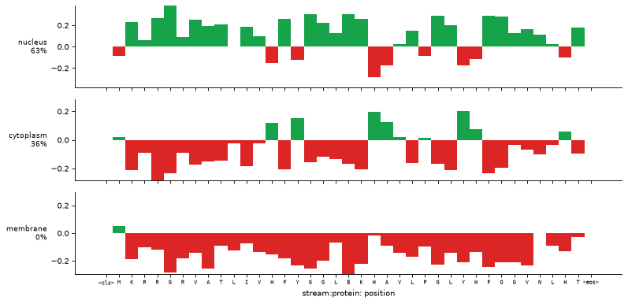

```python
pa
```

**TipHow to read a residue attribution**

A protein is a chain of residues, each written as a letter (M for methionine, K for lysine, and so on), between the markers `<cls>` and `<eos>`. The figure has a panel per option and a bar per residue along the chain: green where the residue raised the option’s log-odds, red where it lowered them, each panel running to its own largest bar. The table above the figure has no *scale* or *words*, since the row’s words didn’t move: only the residues did, from the protein with every residue masked, the baseline, to the protein itself.

The model answers nucleus at 63%, though the gold is cytoplasm, at 36%. From the masked chain to this protein, nucleus’s log-odds rose by 4.01, so its odds grew about 55-fold, and the attributions add up to 3.98. Cytoplasm’s fell by 2.87, and membrane’s by 5.73, to 0%. The bars agree residue after residue, most of them pushing nucleus up, and nearly all pushing membrane down. `by_segment` puts every option’s whole attribution in the protein, since it is the only input that moved. The fixture’s proteins are random letters, about half of each drawn from five amino acids that mark its compartment, so the bars say which letters this little model reacts to, not anything about biology.

### Occlusion

Occlusion asks the backend itself. It hides one piece of the state, asks again, and records how far each option’s log-odds fall, $f_j(x) - f_j(x_{\setminus u})$, for every piece $u$:

- `kind="words"` removes a window of words from a text;
- `kind="residues"` replaces a window of residues with `X`, the unknown residue, so the rest keep their positions;
- `kind="patches"` paints a square of the image black, or another `fill`.

Windows overlap with `stride`, and a unit’s score is the mean over the windows that hid it. It needs only `predict_batch` (or [`predict`](https://sgaseretto.github.io/sysonelib/cli.html#predict)), so it explains any backend, and it can’t drift from the model, since every number is one of the model’s own answers. A backend that rounds its probabilities, as a [`Decider`](https://sgaseretto.github.io/sysonelib/inference.html#decider) does to four decimals, is asked unrounded while occlusion runs, since a probability rounded to 0 has no logarithm. It costs one answer per window. By default it explains the answer and the gold, since the options the model already rules out are mostly noise. `key` names the part of a structured state to occlude, and is found by itself for an [`image`](https://sgaseretto.github.io/sysonelib/cli.html#image), a `sequence` or a `text`.

[figure not shown]

Occlusion on a keyword backend: windows of two words, each hiding two words and asking again, the drop of each, and each word’s score as the mean of its windows’ drops, beside windows of one word

Occlusion on a backend whose rule is known (figures): it adds 2 to billing’s logit when it reads *refund*, and 1.5 when it reads *charged*. Each window is one more question to the backend, and a word scores the mean drop of the windows that hid it. With windows of two words, the words beside *charged* and *refund* share their drops, and *refund*, last and so hidden by one window only, keeps all of its own; with windows of one word, only the two keywords score.

[source](https://github.com/sgaseretto/sysonelib/blob/main/sysone/interpret.py#L697)

### occlusion

```python
def occlusion(
    model, state, questions:dict, qid:NoneType=None, key:NoneType=None, kind:str | None=None, window:int | None=None,
    stride:int | None=None, fill:NoneType=None, options:NoneType=None, target:str='logodds', batch_size:int=16,
    gold:NoneType=None
)->__main__.Attribution:
```

*Attributions through any backend: hide a piece of the state at a time (words, a window of residues, a patch of the image) and measure how far each option’s log-odds fall*

```python
ow = occlusion(learn.decider(), "the customer asked for a refund and is angry about the delay", {"action": recs[0]["questions"]["action"]})
test_eq((ow.method, len(ow.parts["words"].texts), ow.parts["words"].scores.shape), ("occlusion", 12, (1, 12)))
op = occlusion(ml.decider(), crecs[5]["state"], cq, gold="blue", window=8, stride=4)
test_eq(op.parts["image"].scores[0].shape[1:], PILImage.open(crecs[5]["state"]["image"]).size[::-1])
os_ = occlusion(pl.decider(), precs[1]["state"], PQ, window=6)
test_eq((type(os_.parts["sequence"]).__name__, len(os_.parts["sequence"].units)), ("SequencePart", len(precs[1]["state"]["sequence"])))
ow
```

**What should the observability system do with this trace?** · answer **human_review** (25%) · occlusion, attributions of log-odds

| option | p | scale | words |
| --- | --- | --- | --- |
| **human_review** | 0.25 | 2.7e-05 | the customer asked for a refund and is angry about the delay |

**Which colour fills the image?** · answer **blue** (34%) · gold **blue** · occlusion, attributions of log-odds

| option | p |  |
| --- | --- | --- |
| **blue** ✓ | 0.34 |  |

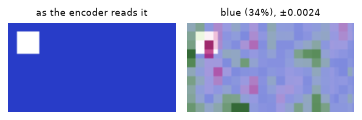

```python
op
```

**TipHow to read an occlusion**

Occlusion’s views look like the others, with a different meaning behind the numbers: each one is how far the option’s log-odds *fall* when that word, patch or stretch of residues is hidden. Green means hiding it lowered the option, so it was evidence for it. Red, or pink on an image, means hiding it raised the option, so it was evidence against. Every number is one of the model’s own answers on a changed input, so there is no Δ or Σ to check: hidings needn’t add up, since a word may matter only beside another.

On the tiny models they are noise again. Hiding any word of *the customer asked for a refund and is angry about the delay* moves human_review’s log-odds by at most 2.7 × 10⁻⁵, and painting squares of the colour image black moves blue’s by thousandths: its map saturates at ±0.0024.

`interp.explain(i)` explains decision `i` of an interpretation, with its record’s gold. Through a sysone model it uses [`attribute`](https://sgaseretto.github.io/sysonelib/interpret.html#attribute), and through any other backend only occlusion:

[source](https://github.com/sgaseretto/sysonelib/blob/main/sysone/interpret.py#L767)

### Interpretation.explain

```python
def explain(
    i:int, method:str='ig', **kw
)->__main__.Attribution:
```

*The attribution of decision `i`: through the model when the backend is a sysone one, by occlusion otherwise*

```python
e = interp.explain(int(interp.top_losses(1)[1][0]))
test_eq(e.gold >= 0, True)
e
```

**How severe is the potential impact if this alert is real?** · answer **0** (20%) · gold **1** · ig, attributions of log-odds

| option | p | Δ | Σ | scale | words |
| --- | --- | --- | --- | --- | --- |
| **0** | 0.20 | +3.5e-05 | +3.4e-05 | 5.1e-05 | [CLS] score question: How severe is the potential impact if this alert is real? [SEP] ▸ level 0: Negligible: no access to anything sensitive. ▸ level 1: Low: limited access, easily reversed. ▸ level 2… |
| **4** | 0.20 | -2.3e-05 | +5e-06 | 3.8e-05 | [CLS] score question: How severe is the potential impact if this alert is real? [SEP] ▸ level 0: Negligible: no access to anything sensitive. ▸ level 1: Low: limited access, easily reversed. ▸ level 2… |
| **3** | 0.20 | +2.9e-05 | -1.1e-05 | 3.8e-05 | [CLS] score question: How severe is the potential impact if this alert is real? [SEP] ▸ level 0: Negligible: no access to anything sensitive. ▸ level 1: Low: limited access, easily reversed. ▸ level 2… |
| **1** ✓ | 0.20 | -9.3e-06 | +2.1e-05 | 3e-05 | [CLS] score question: How severe is the potential impact if this alert is real? [SEP] ▸ level 0: Negligible: no access to anything sensitive. ▸ level 1: Low: limited access, easily reversed. ▸ level 2… |
| **2** | 0.20 | -3.2e-05 | -4.9e-05 | 2.5e-05 | [CLS] score question: How severe is the potential impact if this alert is real? [SEP] ▸ level 0: Negligible: no access to anything sensitive. ▸ level 1: Low: limited access, easily reversed. ▸ level 2… |

This is the decision with the largest loss: a severity rated on five levels, gold 1, answered 0, every level at 20%. Δ, Σ and the scales are again around 10⁻⁵, so the answer doesn’t depend on the alert at all.

## How far to trust an attribution

An attribution is a model of the model, and each method can mislead in its own way. Three checks catch most of it, and the tutorial runs them on real models.

- **Completeness.** Integrated gradients’ attributions must add up to the change of the output from the baseline. The table shows both, Δ and Σ, and marks a row with ⚠ when they are further apart than 0.1 + 10% of the change. Then the integral is wrong, and more steps should close the gap. When more steps don’t, the model’s output is not smooth along the line, and the attributions are not to be trusted.
- **Agreement.** Occlusion measures something else, the model’s actual answer without a piece. When integrated gradients and occlusion rank the same words or patches first, both are probably right.
- **Sanity.** An attribution should change when the model changes. A map that looks the same for a trained head and a random one is showing the input, not the model ([Adebayo et al., 2018](https://arxiv.org/abs/1810.03292)).

[`attribution_path`](https://sgaseretto.github.io/sysonelib/interpret.html#attribution_path) shows the line itself: an option’s log-odds at points from the baseline (α = 0) to the input (α = 1). Integrated gradients integrates the slope of this curve, so a smooth curve is one it can integrate, and a jagged one is a warning. On the fixture’s little model, the curve is smooth, and the 32 steps are plenty:

**NoteFinding: integrated gradients’ attributions didn’t add up on the real encoders**

Integrated gradients is exact only if its integral is computed well, and on the real encoders it often wasn’t.

- **Text, frozen.** With the text application’s default, ModernBERT-large frozen under the anchor head and trained on 900 tweets, the attributions of an option’s log-probability (the target then) missed its change by up to several nats with 32, 64 or 128 steps, from a `[PAD]`, `[MASK]` or `[UNK]` baseline. Along the line, the log-probability moved by up to 1.3 between points 1/200 apart, and zoomed in, by 0.7 within 6 · 10⁻⁵: continuous but jagged. CPU and MPS traced the same curve, so this is the model and not the arithmetic. Even 2,049 exact gradients, summed with the trapezoid rule, missed by up to 3.6, with a sign that changed as the grid got finer.
- **Text, with LoRA.** In the tutorial, the line is smooth but steep, and the answer’s attributions stay within 0.35 of a change of 6.53 from 16 steps to 256. Other options miss by a fifth to a quarter.
- **Pixels.** Through ModernVBERT’s vision tower, from a black image, the sums missed by a sixth to more than the whole change, some with the wrong sign (−12.69 against +3.55).
- **Residues.** Through ESM-1b from `<mask>`, the attributions of 12 confident proteins in each of four compartments missed their changes by a median of 36% to 57% (the log-probability as the target). Zero vectors, which is what ESM’s token dropout feeds the encoder for a masked residue, did no better.

So an [`Attribution`](https://sgaseretto.github.io/sysonelib/interpret.html#attribution) reports the change and the sum side by side, and marks the options where they disagree. There, read the attributions as rough at best, and ask occlusion, which needs no integral.

**NoteFinding: a protein’s attribution held 20 GB**

The first protein attribution ran eight integrated-gradient steps per batch through ESM-1b, a 650-million-parameter encoder of 33 layers, over a protein of 395 residues. A backward pass keeps every layer’s activations for each step, and with eight steps the process grew to 20 GB on an 18 GB laptop, where it thrashed swap until it was stopped. One step per batch held 5.6 GB, and took 28 s for two options. [`attribute`](https://sgaseretto.github.io/sysonelib/interpret.html#attribute) now measures the memory one step keeps for its backward pass before it runs, from the tensors autograd saves, and fits as many steps per batch as `memory`, 2 GB by default, holds. A tweet gets 30 steps per batch, and a protein of 400 to 500 residues one or two even with 4 GB. A larger budget pays where the memory is there: a digit’s attribution through ModernVBERT took 93 s with 2 GB, a step per batch, and 12 s with 6 GB, four steps per batch.

[source](https://github.com/sgaseretto/sysonelib/blob/main/sysone/interpret.py#L775)

### attribution_path

```python
def attribution_path(
    model, builder:sysone.template.RowBuilder, state, questions:dict, qid:NoneType=None, option:NoneType=None,
    inputs:NoneType=None, steps:int=200, baseline:str='pad', temperatures:dict | None=None, target:str='logodds',
    lo:float=0.0, hi:float=1.0
)->tuple:
```

*The points α from `lo` to `hi` and an option’s log-odds (or `target`) there, on the line integrated gradients integrates over: baseline at α = 0, input at α = 1*

```python
al, fl = attribution_path(learn.model, learn.data.builder, recs[0]["state"], recs[0]["questions"], "action", option="stop")
ga = learn.explain(recs[0]["state"], recs[0]["questions"], "action", options=["stop"])
test_eq((len(al), len(fl)), (200, 200))
test_close((fl[0], fl[-1]), (ga.f_baseline[0], ga.f_input[0]), eps=1e-4)            # the line runs from the baseline to the row
fig, ax = plt.subplots(figsize=(5, 2.2))
ax.plot(al, fl, lw=1.5); ax.set(xlabel="α: from the baseline (0) to the row (1)", ylabel="log-odds of stop")
plt.tight_layout(); plt.show()
```

[figure not shown]

**TipHow to read the path**

The x axis runs from the baseline, α = 0, to the real row, α = 1, and the curve is the option’s log-odds at each point on the way. Integrated gradients adds up the slope of this curve, so its attributions can add up only where the curve is smooth enough for its 32 points. A jagged or stepped curve is a warning.

Mind the axis: its label, *1e−5 −1.098*, means each tick is −1.098 plus that many hundred-thousandths. Stop’s log-odds sit at −1.0986, which is log(0.25/0.75), the log-odds of 25%, from one end to the other, drifting down by 8 × 10⁻⁵ on the way. The curve is smooth, so the attributions add up; it is also flat, so there is nothing for them to find.